# Networks

follow along with code: https://dmontagne.github.io/Data-Analytics-Teaching-Material/network_analysis_code.R

### Agenda:

- Visualize a social network
- Build a topic model

### Install and Load Packages

```r
install.packages("igraph")
install.packages("stm")
```

### Install and Load Packages

```r
library(igraph)
library(stm)
library(dplyr)
library(tidyverse)
```

### Load in Data

- Data was collected through Spotify.com
- All artists on Spotify's “Today's Top Hits” playlist, and those Spotify suggests as “Related Artists”

### Load in Data

```r
download.file("https://github.com/dmontagne/Data-Analytics-Teaching-Material/blob/master/Music%20Network%20Data/artist_edges.Rda?raw=true", "git_edges")
load("git_edges")

download.file("https://github.com/dmontagne/Data-Analytics-Teaching-Material/blob/master/Music%20Network%20Data/vertices_info.Rda?raw=true", "git_vertices")
load("git_vertices")
```

### Make Network Object

```r
artist_network <- graph.data.frame(artist_edges[, -1], directed=F) # , vertices=vertices_info
```

### Visualize Network

```r
# Let's plot our network
plot(artist_network,
     layout = layout.fruchterman.reingold(artist_network),
     vertex.size = .5,
     vertex.label = V(artist_network)$simple_labels)
```

### Visualize Network

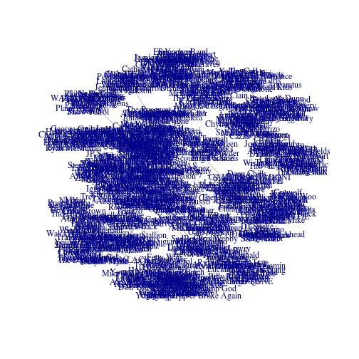

### Visualize Network

- That looked bad

### Visualize Network

- Let's filter by degree
- Info we need:

```r
degree(artist_network)
V(artist_network)$name
```

### Visualize Network

```r
V(artist_network)$simple_labels <- ifelse(
  # If an artist's degree is less than 20, don't give it a label (`NA`)
  degree(artist_network) < 20, NA,
  # If an artist's degree is 20 or more, however, label it with the artist's
  # name (stored in `V(artist_network)$name`)
  V(artist_network)$name)
```

### Visualize Network (again)

```r
plot(artist_network,
     layout = layout.fruchterman.reingold(artist_network),
     vertex.size = 1,
     vertex.label = V(artist_network)$simple_labels)
```

### Visualize Network (again)

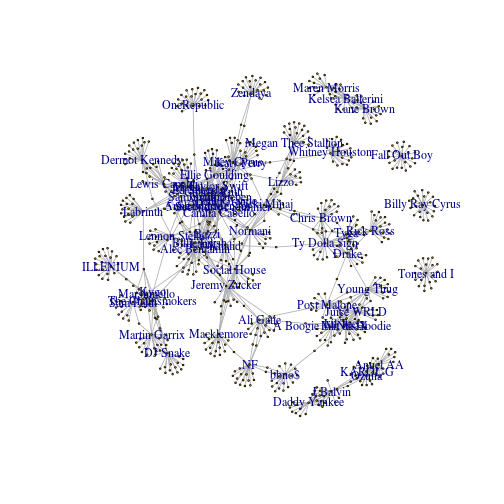

### Individual Level Measures (vertices)

```r
betweenness(artist_network, v = V(artist_network), directed = F)
```

```
                Post Malone                  Young Thug
               1.884683e+04                1.660601e+04
                  Sam Smith                Shawn Mendes
               1.953122e+04                2.647440e+03
             Camila Cabello               Lewis Capaldi
               8.833829e+03                1.364750e+04
              Ariana Grande                Social House
               1.578434e+04                1.562469e+04
               Taylor Swift                  Ed Sheeran
               7.176686e+03                9.270005e+03
                     Khalid                   Lil Tecca
               2.944932e+04                7.506658e+03
                Tones and I               Billie Eilish
               1.900000e+02                2.117403e+04
              Justin Bieber                       Bazzi
               5.001914e+03                1.869479e+04
                       Lauv                  Anne-Marie
               3.009735e+04                1.278464e+04
                Miley Cyrus                       Lizzo
               1.878086e+04                1.317622e+04
        Megan Thee Stallion                 Nicki Minaj
               1.049289e+04                3.657151e+04
              Ty Dolla $ign                 Chris Brown
               1.873563e+04                7.756268e+03
                      Drake            The Chainsmokers
               2.654761e+04                2.035613e+04
                   ILLENIUM               Lennon Stella
               1.227400e+04                8.932369e+03
     A Boogie Wit da Hoodie                     Normani
               7.194964e+03                1.371706e+04
                   DJ Snake                    J Balvin
               8.493284e+03                9.262402e+02
                       Tyga                   Ali Gatie
               9.088344e+03                2.283207e+04
                         NF                   Lil Nas X
               1.950584e+04                5.416962e+03
                      bbno$                  Katy Perry
               1.117911e+04                9.857603e+03
                   Anuel AA                Daddy Yankee
               4.442167e+02                4.530000e+02
```

[output cut: 767 more lines]

```
               0.000000e+00                0.000000e+00
                  Lifehouse                   Parachute
               0.000000e+00                0.000000e+00
               Gavin DeGraw                    Owl City
               0.000000e+00                0.000000e+00
                Snow Patrol             Plain White T's
               0.000000e+00                0.000000e+00
                Mat Kearney                Andy Grammer
               0.000000e+00                0.000000e+00
          Five For Fighting             Imagine Dragons
               0.000000e+00                0.000000e+00
                      Keane               WALK THE MOON
               0.000000e+00                0.000000e+00
                   Daughtry
               0.000000e+00
```

```r
closeness(artist_network, v = V(artist_network))
```

```
                Post Malone                  Young Thug
               7.235576e-06                7.225016e-06
                  Sam Smith                Shawn Mendes
               7.271247e-06                7.270612e-06
             Camila Cabello               Lewis Capaldi
               7.275796e-06                7.254683e-06
              Ariana Grande                Social House
               7.273045e-06                7.270242e-06
               Taylor Swift                  Ed Sheeran
               7.263430e-06                7.264485e-06
                     Khalid                   Lil Tecca
               7.283639e-06                7.212509e-06
                Tones and I               Billie Eilish
               1.522487e-06                7.275479e-06
              Justin Bieber                       Bazzi
               7.264696e-06                7.282685e-06
                       Lauv                  Anne-Marie
               7.284064e-06                7.269397e-06
                Miley Cyrus                       Lizzo
               7.252841e-06                7.244172e-06
        Megan Thee Stallion                 Nicki Minaj
               7.223763e-06                7.274103e-06
              Ty Dolla $ign                 Chris Brown
               7.252210e-06                7.231704e-06
                      Drake            The Chainsmokers
               7.247060e-06                7.247480e-06
                   ILLENIUM               Lennon Stella
               7.215736e-06                7.257842e-06
     A Boogie Wit da Hoodie                     Normani
               7.211937e-06                7.271987e-06
                   DJ Snake                    J Balvin
               7.186748e-06                1.596042e-06
                       Tyga                   Ali Gatie
               7.240186e-06                7.252368e-06
                         NF                   Lil Nas X
               7.224911e-06                7.197248e-06
                      bbno$                  Katy Perry
               7.171852e-06                7.250843e-06
                   Anuel AA                Daddy Yankee
               1.596014e-06                1.595899e-06
```

[output cut: 767 more lines]

```
               7.177669e-06                7.177669e-06
                  Lifehouse                   Parachute
               7.177669e-06                7.177669e-06
               Gavin DeGraw                    Owl City
               7.177669e-06                7.177669e-06
                Snow Patrol             Plain White T's
               7.177669e-06                7.177669e-06
                Mat Kearney                Andy Grammer
               7.177669e-06                7.177669e-06
          Five For Fighting             Imagine Dragons
               7.177669e-06                7.177669e-06
                      Keane               WALK THE MOON
               7.177669e-06                7.177669e-06
                   Daughtry
               7.177669e-06
```

### Network Level Measures

```r
edge_density(artist_network)
```

```
[1] 0.003862036
```

```r
transitivity(artist_network)
```

```
[1] 0.09257732
```

### Clustering

- There are many, many, many clustering algorithms
- We are going to look at only one, edge betweenness based community structure
  - The idea behind this algorithm is that it is likely that edges connecting separate modules have high edge betweenness as all the shortest paths from one module to another must traverse through them
  - `cluster_edge_betweenness` performs this algorithm by calculating the edge betweenness of the graph, removing the edge with the highest edge betweenness score, then recalculating edge betweenness of the edges and again removing the one with the highest score, and so on

### Clustering

Perform Algorithm:

```r
artist_clusters <- cluster_edge_betweenness(artist_network)
```

Extract relevant information:

```r
artist_groups <- data.frame("artist" = artist_clusters$names, "group" = artist_clusters$membership)
```

### Clustering

- Now we should explore the groups!
- Open the dataframe, and sort by `group`. Artists with the same number are part of the same cluster.
  - Do these groups make sense?

### Topic Modeling

[figure not shown]

### Structural Topic Modeling

- Various algorithms
- Structural Topic Modeling allows for the implementation of *meta-data*

### Structural Topic Modeling

Our data: Lyrics from all* songs of artists that are in our network sample

- *there is some missing data on both songs and artists

```r
download.file("https://github.com/dmontagne/Data-Analytics-Teaching-Material/blob/master/lyrics_corpus.Rda?raw=true", "git_lyrics")
load("git_lyrics")
```

### Structural Topic Modeling

- This is a lot of data
  - We have 71,553 songs, with around 403,348 unique words
  - We are going to randomly choose 1 song per artist, for a total of 751 songs
  - Even then, there is too much data to go through by hand and identify topics
  - We will use the package `stm`

### Prep Data STM

- We need to prepare our data to be in the right format for processing
- Taking out “stopwords”, remove punctuation, make everything lowercase
- Making “document-term matrix”

### Prep Data STM

- This takes a few minutes

```r
lyrics_sample <- lyrics_sample %>% group_by(artist_id) %>% sample_n(., 1)
metadata_lyrics <- lyrics_sample %>%
  select(artist_id)
process_lyrics <- textProcessor(lyrics_sample$lyrics, metadata = metadata_lyrics)
```

### Prep Data STM

```r
prep_lyrics <- prepDocuments(process_lyrics$documents, process_lyrics$vocab, process_lyrics$meta)
```

### Modeling STM

- We have to choose how many topics to sort the data into
- How?

### Modeling STM

```r
which_k <- searchK(prep_lyrics$documents, prep_lyrics$vocab, K = seq(10, 50, by = 10),
                      data = prep_lyrics$meta, verbose = T)
```

### Modeling STM

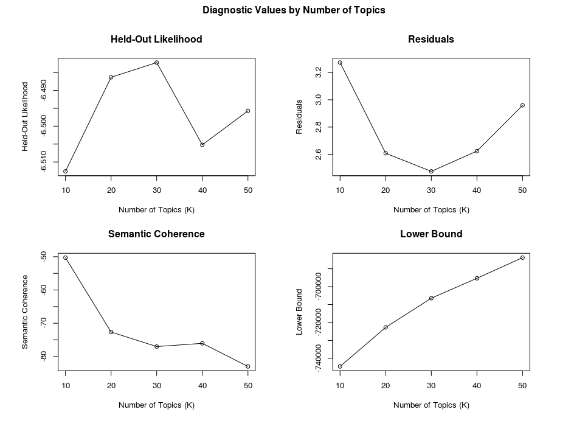

### Modeling STM

- 30 topics looks to be the best fit

### Modeling STM

```r
lyrics_30 <-  stm(documents = prep_lyrics$documents,
                  vocab = prep_lyrics$vocab,
                  K = 30,
                  data = prep_lyrics$meta,
                  init.type = "Spectral",
                  verbose = F)
```

### Exploring Topics

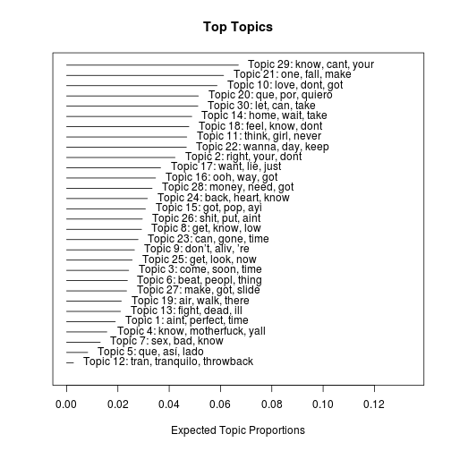

```r
plot.STM(lyrics_30)
```

### Exploring Topics

```r
labelTopics(lyrics_30)
```

### Exploring Topics

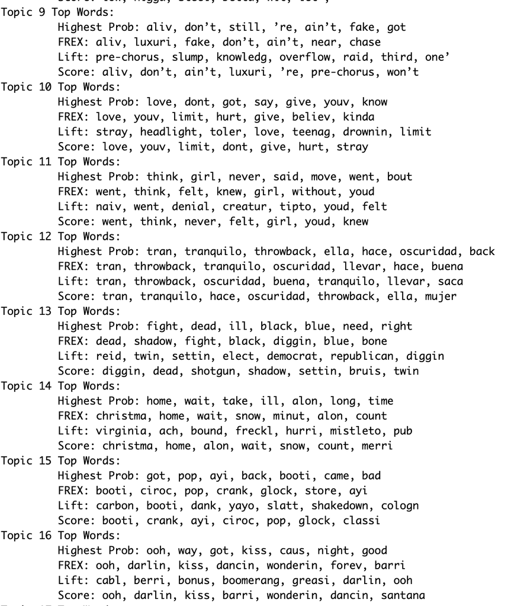

### Exploring Topics

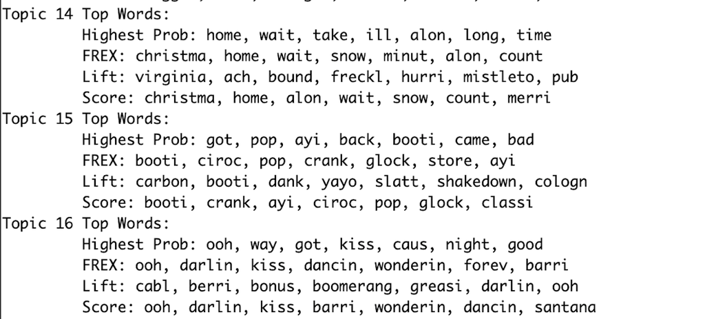